# HW4

Sokona Mangane

2023-02-08

# Unifrom Random Variates:

1. Write an R function names `myunif` that accepts three parameters: `n`, the number of variates to generate; `a`, the lower limit of the distribution; and `b`, the upper limit of the distribution.

Your function must return a vector of *n uniform (a, b)* random variates. Each variate must be generated by inverting a single call to `runif(1)` — use the idf determined by setting $u = F (x)$ and solving for $x$ (you are not permitted to use `qunif`).

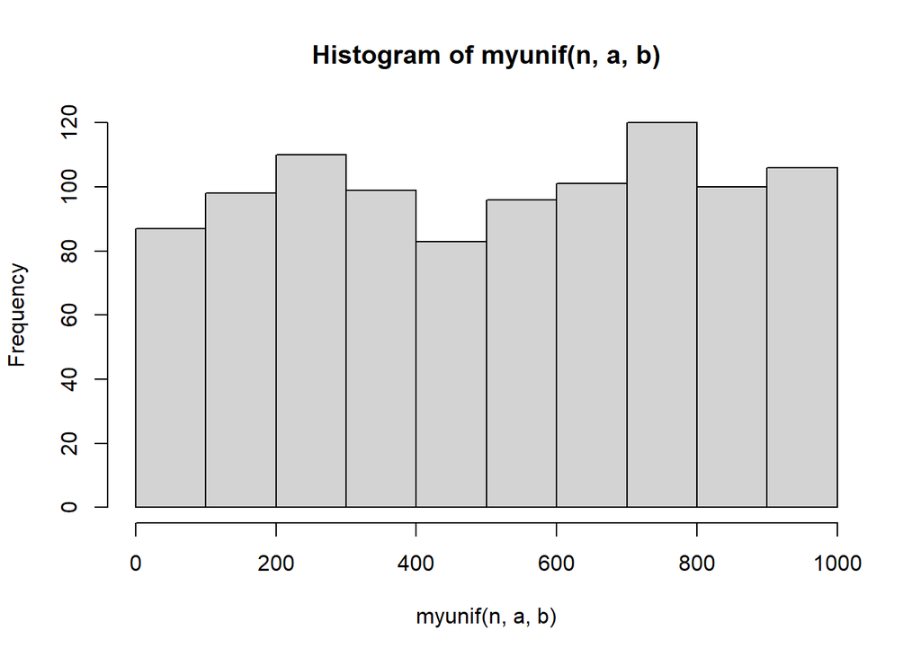

```r
myunif <- function(n, a, b){
  values = rep(0,n)
  for(i in 0:n){
    values[i] = a + ((b-a)*(runif(1)))
  }
  return(values)
}

a = 0
b = 1000
n = 1000

hist(myunif(n, a, b))
```

2. Using your `myunif` function, produce a histogram of many *uniform (a, b)* random variates, superimposing the true theoretical distribution (see `dunif`).

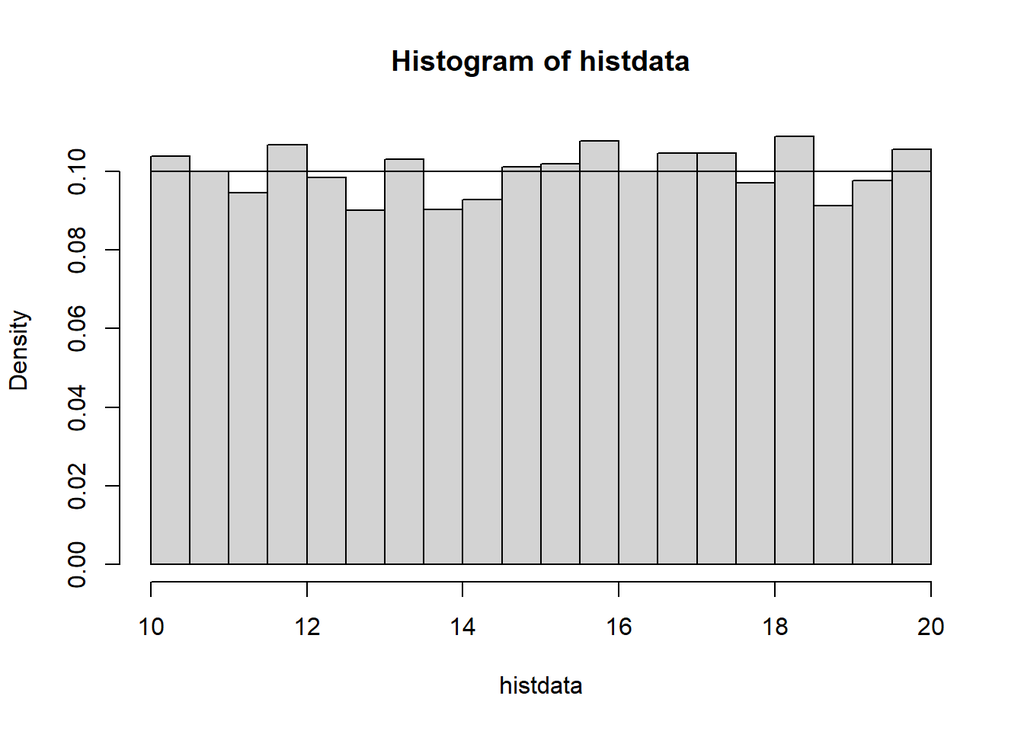

```r
histdata = myunif(10000, 10, 20)
x <- seq(10,20, by = 0.01)
hist(histdata, freq = FALSE)
curve(dunif(x, 10, 20), add = TRUE)
```

3. Confirm that the mean and standard deviation of your random variate sample are consistent with the theoretical values given above

```r
tmean = (a + b)/2 #theoretical mean
tsd = (b - a) / sqrt(12) #theoretical sd

mean(histdata) == tmean
```

```
## [1] FALSE
```

```r
sd(histdata) == tsd
```

```
## [1] FALSE
```

# Triangular Random Variates

Often, the only data known about a real-world distribution is its minimum value, its maximum value, and its most likely value (mode). In such a case, the *triangular* distribution is appropriate. Let the random variable X be *triangular (a, b, c)* where *a* is the minimum value, *b* is the maximum value, and *c* is the mode.

4. Write an R function named `mytriang` that accepts four parameters: `n`, the number of variates to generate; `a`, the lower limit of the distribution; `b`, the upper limit of the distribution; and `c`, the mode of the distribution.

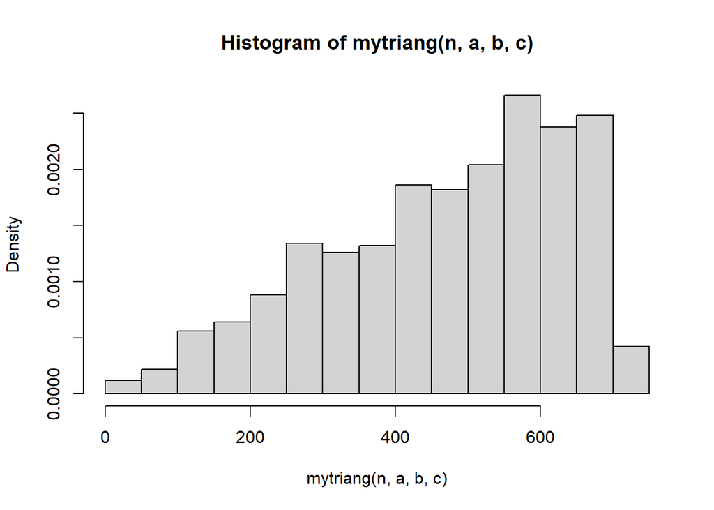

```r
mytriang <- function(n, a, b, c){
  values = rep(0,n)
  if(a < runif(1) & runif(1) < c) {
    for(i in 0:n){
      d = (b - a)*(c - a)
      values[i] = a + (sqrt(d * runif(1)))
    }

  if(c < runif(1) & runif(1) < b) {
    for (i in 0:n) {
      d = (b - a)*(b - c)*(1 - (runif(1)))
      values[i] = b - (sqrt(d))
      }
  }
  }
  return(values)
}

a = 0
b = 1000
c = 500
n = 1000

hist(mytriang(n, a, b, c), freq = FALSE)
```

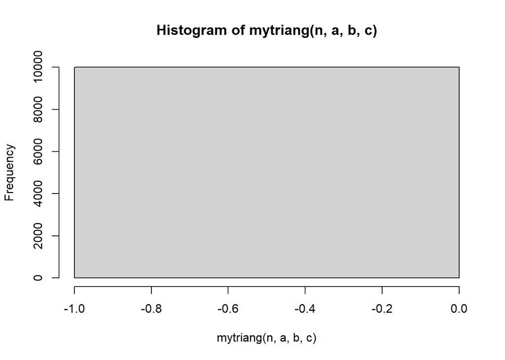

```r
a = 10
b = 25
c = 15
n = 10000

histdata1 = mytriang(n, a, b, c)
hist(mytriang(n, a, b, c)) #looks like a uniform distribution from -1 to 0
segments(a,0, c, (2/(b-a)))
segments(c, (2/(b-a)), b, 0)
```

6. Confirm that the mean and standard deviation of your random variate sample are consistent with the theoretical values given below.

```r
ttriangmean = (a + b + c)/3 #theoretical triangular mean
ttriangsd = sqrt((1/18) * ((a^2) + (b^2) + (c^2) - (a*b) - (a*c) - (b*c))) #theoretical triangular sd

mean(histdata1) == ttriangmean
```

```
## [1] FALSE
```

```r
sd(histdata1) == ttriangsd
```

```
## [1] FALSE
```